```python
import pandas as pd
import numpy as np
import matplotlib.pyplot as plt
import seaborn as sns

from sklearn.metrics import accuracy_score
```

We have chosen the Pokémon dataset from https://www.kaggle.com/datasets/abcsds/pokemon . Our objective is to classify Pokémon types based on the stats and find the model and hyperparameters with the best performance. There are multiple ways of going about this. But first, let's explore the dataset.

# Exploring the dataset

```python
# import the dataset
df = pd.read_csv('data/Pokemon.csv')

original_df = df.copy()
# Print head
df.head()
```

|  | # | Name | Type 1 | Type 2 | Total | HP | Attack | Defense | Sp. Atk | Sp. Def | Speed | Generation | Legendary |
| --- | --- | --- | --- | --- | --- | --- | --- | --- | --- | --- | --- | --- | --- |
| 0 | 1 | Bulbasaur | Grass | Poison | 318 | 45 | 49 | 49 | 65 | 65 | 45 | 1 | False |
| 1 | 2 | Ivysaur | Grass | Poison | 405 | 60 | 62 | 63 | 80 | 80 | 60 | 1 | False |
| 2 | 3 | Venusaur | Grass | Poison | 525 | 80 | 82 | 83 | 100 | 100 | 80 | 1 | False |
| 3 | 3 | VenusaurMega Venusaur | Grass | Poison | 625 | 80 | 100 | 123 | 122 | 120 | 80 | 1 | False |
| 4 | 4 | Charmander | Fire | NaN | 309 | 39 | 52 | 43 | 60 | 50 | 65 | 1 | False |

```python
# Print info such as data types and number of non-null values
df.info()
```

```
<class 'pandas.core.frame.DataFrame'>
RangeIndex: 800 entries, 0 to 799
Data columns (total 13 columns):
 #   Column      Non-Null Count  Dtype
---  ------      --------------  -----
 0   #           800 non-null    int64
 1   Name        800 non-null    object
 2   Type 1      800 non-null    object
 3   Type 2      414 non-null    object
 4   Total       800 non-null    int64
 5   HP          800 non-null    int64
 6   Attack      800 non-null    int64
 7   Defense     800 non-null    int64
 8   Sp. Atk     800 non-null    int64
 9   Sp. Def     800 non-null    int64
 10  Speed       800 non-null    int64
 11  Generation  800 non-null    int64
 12  Legendary   800 non-null    bool
dtypes: bool(1), int64(9), object(3)
memory usage: 75.9+ KB
```

```python
# Print summary statistics of numeric types
df.describe()
```

|  | # | Total | HP | Attack | Defense | Sp. Atk | Sp. Def | Speed | Generation |
| --- | --- | --- | --- | --- | --- | --- | --- | --- | --- |
| count | 800.000000 | 800.00000 | 800.000000 | 800.000000 | 800.000000 | 800.000000 | 800.000000 | 800.000000 | 800.00000 |
| mean | 362.813750 | 435.10250 | 69.258750 | 79.001250 | 73.842500 | 72.820000 | 71.902500 | 68.277500 | 3.32375 |
| std | 208.343798 | 119.96304 | 25.534669 | 32.457366 | 31.183501 | 32.722294 | 27.828916 | 29.060474 | 1.66129 |
| min | 1.000000 | 180.00000 | 1.000000 | 5.000000 | 5.000000 | 10.000000 | 20.000000 | 5.000000 | 1.00000 |
| 25% | 184.750000 | 330.00000 | 50.000000 | 55.000000 | 50.000000 | 49.750000 | 50.000000 | 45.000000 | 2.00000 |
| 50% | 364.500000 | 450.00000 | 65.000000 | 75.000000 | 70.000000 | 65.000000 | 70.000000 | 65.000000 | 3.00000 |
| 75% | 539.250000 | 515.00000 | 80.000000 | 100.000000 | 90.000000 | 95.000000 | 90.000000 | 90.000000 | 5.00000 |
| max | 721.000000 | 780.00000 | 255.000000 | 190.000000 | 230.000000 | 194.000000 | 230.000000 | 180.000000 | 6.00000 |

```python
# Check for missing values
print(df.isnull().sum())
```

```
#               0
Name            0
Type 1          0
Type 2        386
Total           0
HP              0
Attack          0
Defense         0
Sp. Atk         0
Sp. Def         0
Speed           0
Generation      0
Legendary       0
dtype: int64
```

Some pokémon don't have a second type. We'll need to handle these missing values later

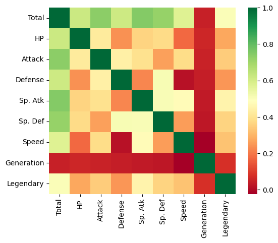

```python
# Plot the correlation matrix
sns.heatmap(df.drop(['#', 'Name'], axis=1).select_dtypes(include=[np.number, bool]).corr(), square=True, cmap='RdYlGn');
```

As you can see, the stat total is correlated with the 6 main stats (HP, attack, defense, sp. attack, sp. defense & speed), which makes sense, as it is the summation of these stats.

Also, the generation is not really correlated (much) with anything other than itself. This is not too surprising, as each generation introduces a wide variety of new Pokémon. (The slightly higher correlation with whether the Pokémon is legendary or not, does reflect that later generations featured higher ratios of legendaries among the new Pokémon of that generation than earlier generations.)

The lack of correlation between speed and defense is also something that stands out in this visualisation.

# Common preprocessing steps

```python
# Drop the Name and ID columns
df.drop(['#', 'Name'], axis=1, inplace=True)
# Covert the Legendary column from bool to int
df.Legendary = df.Legendary.astype(int)
# Print the head of the dataframe
df.head()
```

|  | Type 1 | Type 2 | Total | HP | Attack | Defense | Sp. Atk | Sp. Def | Speed | Generation | Legendary |
| --- | --- | --- | --- | --- | --- | --- | --- | --- | --- | --- | --- |
| 0 | Grass | Poison | 318 | 45 | 49 | 49 | 65 | 65 | 45 | 1 | 0 |
| 1 | Grass | Poison | 405 | 60 | 62 | 63 | 80 | 80 | 60 | 1 | 0 |
| 2 | Grass | Poison | 525 | 80 | 82 | 83 | 100 | 100 | 80 | 1 | 0 |
| 3 | Grass | Poison | 625 | 80 | 100 | 123 | 122 | 120 | 80 | 1 | 0 |
| 4 | Fire | NaN | 309 | 39 | 52 | 43 | 60 | 50 | 65 | 1 | 0 |

We will handle the missing values by filling it up by a 'None' type

```python
# Handling missing values in 'Type 2' column
df['Type 2'] = df['Type 2'].fillna('None')


print(df.isnull().sum())
df.head()
```

```
Type 1        0
Type 2        0
Total         0
HP            0
Attack        0
Defense       0
Sp. Atk       0
Sp. Def       0
Speed         0
Generation    0
Legendary     0
dtype: int64
```

|  | Type 1 | Type 2 | Total | HP | Attack | Defense | Sp. Atk | Sp. Def | Speed | Generation | Legendary |
| --- | --- | --- | --- | --- | --- | --- | --- | --- | --- | --- | --- |
| 0 | Grass | Poison | 318 | 45 | 49 | 49 | 65 | 65 | 45 | 1 | 0 |
| 1 | Grass | Poison | 405 | 60 | 62 | 63 | 80 | 80 | 60 | 1 | 0 |
| 2 | Grass | Poison | 525 | 80 | 82 | 83 | 100 | 100 | 80 | 1 | 0 |
| 3 | Grass | Poison | 625 | 80 | 100 | 123 | 122 | 120 | 80 | 1 | 0 |
| 4 | Fire | None | 309 | 39 | 52 | 43 | 60 | 50 | 65 | 1 | 0 |

We copy the dataframe to use it later

```python
preprocessed_df = df.copy()
```

As stated before, there are many ways to classify multipe classes.

1. **Multiclass Classification**:
- 1.1. Accounting for Order of Types
  - For this task, we need to make every possible combination a class, where the order of types matters.
  - We can consider using classifiers like:
    - `tree.DecisionTreeClassifier`
    - `neighbors.KNeighborsClassifier`
    - `linear_model.LogisticRegression`
    - `ensemble.RandomForestClassifier`
    - `svm.SVC`
- 1.2. Ignoring Order of Types:
  - For this task, where the order of types doesn't matter, the same classifiers as above can be used. We just need to ensure that our encoding of the labels reflects this.
2. **Multilabel Classification**:
- 2.1. Accounting for Order of Types
  - For multilabel classification where each Pokémon can have multiple types and we account for order of types, we can use:
    - `tree.DecisionTreeClassifier`
    - `neighbors.KNeighborsClassifier`
    - `ensemble.RandomForestClassifier`
- 2.2 Ignoring Order of Types
  - For this task, where the order of types doesn't matter, the same classifiers as above can be used. We just need to ensure that our encoding of the labels reflects this.
4. **Multiclass Multioutput Classification**:
   - For multiclass multioutput classification where each Pokémon can have two types predicted independently, we can use classifiers like:
     - `tree.DecisionTreeClassifier`
     - `neighbors.KNeighborsClassifier`
     - `ensemble.RandomForestClassifier`

# Multi-class classification

## Accounting for Order of Types

### Preprocessing

We make a new column 'Types' where the combination of type 1 and type 2 are stored in tuples, which is ordered by default

```python
df = preprocessed_df.copy()

df['Types'] = df[['Type 1', 'Type 2']].apply(lambda x: tuple(filter(lambda y: pd.notna(y), x)), axis=1)
df.Types = df.Types.astype(str)

print(len(df['Types'].unique()))

# print two pokemon types where we know type 1 and two are the same but reversed to check if order is kept into account
print("Sableye: ",df['Types'][326])
print("Spiritomb: ",df['Types'][490])

# drop the Type 1 and Type 2 columns
df.drop(['Type 1', 'Type 2'], axis=1, inplace=True)

# print head
df.head()
```

```
154
Sableye:  ('Dark', 'Ghost')
Spiritomb:  ('Ghost', 'Dark')
```

|  | Total | HP | Attack | Defense | Sp. Atk | Sp. Def | Speed | Generation | Legendary | Types |
| --- | --- | --- | --- | --- | --- | --- | --- | --- | --- | --- |
| 0 | 318 | 45 | 49 | 49 | 65 | 65 | 45 | 1 | 0 | ('Grass', 'Poison') |
| 1 | 405 | 60 | 62 | 63 | 80 | 80 | 60 | 1 | 0 | ('Grass', 'Poison') |
| 2 | 525 | 80 | 82 | 83 | 100 | 100 | 80 | 1 | 0 | ('Grass', 'Poison') |
| 3 | 625 | 80 | 100 | 123 | 122 | 120 | 80 | 1 | 0 | ('Grass', 'Poison') |
| 4 | 309 | 39 | 52 | 43 | 60 | 50 | 65 | 1 | 0 | ('Fire', 'None') |

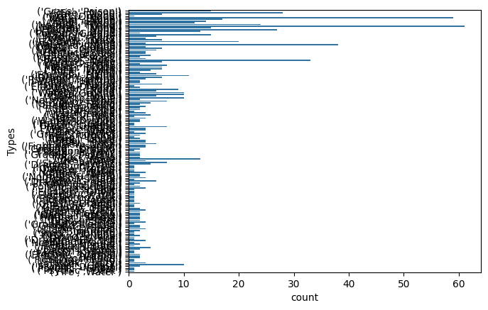

```python
# show the distribution of pokemon types
sns.countplot(df, y='Types');
```

As you can see, the dataset is heavily imbalanced. Some combinations only occur once. We decided to extract them and put them in both train and test sets to stratify the data better.

```python
# Some type combinations only occur once so we double them to stratify the data better
singleton_classes = df['Types'].value_counts()[df['Types'].value_counts() == 1].index.tolist()
singleton_data = df[df['Types'].isin(singleton_classes)]
other_data = df[~df['Types'].isin(singleton_classes)]

print("Number of singleton classes",len(singleton_classes))
print("number of unique type combinations",len(df['Types'].unique()))
print(len(df['Types']))

df.head()
```

```
Number of singleton classes 39
number of unique type combinations 154
800
```

|  | Total | HP | Attack | Defense | Sp. Atk | Sp. Def | Speed | Generation | Legendary | Types |
| --- | --- | --- | --- | --- | --- | --- | --- | --- | --- | --- |
| 0 | 318 | 45 | 49 | 49 | 65 | 65 | 45 | 1 | 0 | ('Grass', 'Poison') |
| 1 | 405 | 60 | 62 | 63 | 80 | 80 | 60 | 1 | 0 | ('Grass', 'Poison') |
| 2 | 525 | 80 | 82 | 83 | 100 | 100 | 80 | 1 | 0 | ('Grass', 'Poison') |
| 3 | 625 | 80 | 100 | 123 | 122 | 120 | 80 | 1 | 0 | ('Grass', 'Poison') |
| 4 | 309 | 39 | 52 | 43 | 60 | 50 | 65 | 1 | 0 | ('Fire', 'None') |

### Decision tree

The single classes are added to both the training and test sets after being stratified on the rest of the data. This makes the actual test size slightly larger.

```python
from sklearn.tree import DecisionTreeClassifier
from sklearn.model_selection import train_test_split
# Split the data into training and testing sets
X = df.drop(columns=['Types'])
y = df['Types']

X_train, X_test, y_train, y_test = train_test_split(other_data.drop(columns=['Types']), other_data['Types'], test_size=0.2, stratify=other_data['Types'], random_state=42)
X_train = pd.concat([X_train, singleton_data.drop(columns=['Types'])])
y_train = pd.concat([y_train, singleton_data['Types']])
X_test = pd.concat([X_test, singleton_data.drop(columns=['Types'])])
y_test = pd.concat([y_test, singleton_data['Types']])

print("actual test size:",len(X_test)/(len(X_train)+len(X_test)))
```

```
actual test size: 0.22884386174016685
```

```python
from sklearn.metrics import accuracy_score, f1_score, fbeta_score

# Initialize and train the decision tree classifier
model = DecisionTreeClassifier(random_state=42)
model.fit(X_train, y_train)

# Predict labels for the test set
y_pred = model.predict(X_test)

# Calculate accuracy
print("Score: ", model.score(X_test, y_test))
accuracy = accuracy_score(y_test, y_pred)
print("Accuracy:", accuracy)
```

```
Score:  0.2604166666666667
Accuracy: 0.2604166666666667
```

#### Hyperparameter Tuning

For hyperparameter tuning we use GridSearchCV and a pipeline with a StandardScaler to make the data more uniform.

```python
# Import GridSearchCV
from sklearn.model_selection import GridSearchCV
from sklearn.model_selection import RandomizedSearchCV
from sklearn.pipeline import make_pipeline
from sklearn.preprocessing import StandardScaler
# Setup the parameters and distributions to sample from: param_dist
pipeline = make_pipeline(StandardScaler(), DecisionTreeClassifier())

param_dist = {
    "decisiontreeclassifier__max_depth": np.arange(5, 15),
    "decisiontreeclassifier__min_samples_leaf": np.arange(1, 5)
}

# Instantiate the GridSearchCV object
grid_search_cv = GridSearchCV(pipeline, param_grid=param_dist, cv=5)

# Fit grid_search_cv using the data X and labels y.
grid_search_cv.fit(X_train, y_train)
y_pred = grid_search_cv.predict(X_test)

# Print the best score
print("Tuned Model Parameters: {}".format(grid_search_cv.best_params_))
print("Accuracy: {}".format(grid_search_cv.best_estimator_.score(X_test, y_test)))
#print(classification_report(y_test, y_pred))
y_pred = grid_search_cv.best_estimator_.predict(X_test)
```

```
Tuned Model Parameters: {'decisiontreeclassifier__max_depth': 8, 'decisiontreeclassifier__min_samples_leaf': 4}
Accuracy: 0.10416666666666667
```

Hyperparameter tuning can sometimes lead to worse results than using default settings. This can occur when the tuning process, typically done via cross-validation on the training data, inadvertently overfits the model. Overfitting happens when the model learns not only the underlying patterns but also the noise in the training data, which reduces its ability to generalize to new, unseen data. This issue is exacerbated when the dataset has classes with very few members, leading to unreliable splits during cross-validation.

### Random forest

```python
from sklearn.ensemble import RandomForestClassifier

model = RandomForestClassifier(random_state=42)

model.fit(X_train, y_train)

# Predict labels for the test set
y_pred = model.predict(X_test)
score = model.score(X_test, y_test)
# Calculate accuracy
print("Score :", score )
accuracy = accuracy_score(y_test, y_pred)
print("Accuracy:", accuracy)
```

```
Score : 0.3072916666666667
Accuracy: 0.3072916666666667
```

#### Hyperparameter Tuning

```python
# Import GridSearchCV
pipeline = make_pipeline(StandardScaler(), RandomForestClassifier())

# Setup the parameters and distributions to sample from: param_dist
param_dist = {
    "randomforestclassifier__max_depth": np.arange(5, 20),
    "randomforestclassifier__min_samples_leaf": np.arange(1, 10),
    "randomforestclassifier__n_estimators": np.arange(50, 150, 5)
}

# Instantiate the RandomizedSearchCV object: random_grid_search_cv
random_search_cv = RandomizedSearchCV(pipeline, param_distributions=param_dist, n_iter=100, cv=3, random_state=42)
#grid_search_cv = GridSearchCV(pipeline, param_grid=param_dist, cv=3)

# Fit random_search_cv using the data X and labels y
random_search_cv.fit(X_train, y_train)
#grid_search_cv.fit(X_train, y_train)

# Print the best score
print("Best score is {}".format(random_search_cv.best_estimator_.score(X_test, y_test)))
print("Best parameters are {}".format(random_search_cv.best_params_))
```

```
Best score is 0.3020833333333333
Best parameters are {'randomforestclassifier__n_estimators': 85, 'randomforestclassifier__min_samples_leaf': 3, 'randomforestclassifier__max_depth': 15}
```

### Support Vector Machine

#### Radial base function

```python
from sklearn.svm import SVC

model = SVC(kernel='rbf', random_state=42)

model.fit(X_train, y_train)
y_pred = model.predict(X_test)

# Calculate accuracy
accuracy = accuracy_score(y_test, y_pred)
print("Accuracy:", accuracy)
```

```
Accuracy: 0.078125
```

##### Hyperparameter Tuning

```python
from sklearn.svm import SVC

# Define the pipeline with StandardScaler and SVC
pipeline = make_pipeline(StandardScaler(), SVC(kernel='rbf'))

# Define the parameter grid
param_grid = {
    'svc__C': [0.1,0.5, 1,5, 10],        # Regularization parameter
    'svc__coef0': [0.0, 1.0, 2.0], # Independent term in the polynomial kernel function
}

# Initialize GridSearchCV
grid_search = GridSearchCV(pipeline, param_grid, cv=5, n_jobs=-1)

# Perform grid search
grid_search.fit(X_train, y_train)

# Get the best parameters and score
best_params = grid_search.best_params_
best_score=grid_search.best_estimator_.score(X_test, y_test)

print("Best Parameters:", best_params)
print("Best score is {}".format(grid_search.best_estimator_.score(X_test, y_test)))
```

```
Best Parameters: {'svc__C': 5, 'svc__coef0': 0.0}
Best score is 0.21354166666666666
```

#### Linear

```python
svm_classifier = SVC(kernel='linear', random_state=42)

# Train the SVM classifier
svm_classifier.fit(X_train, y_train)
y_pred = svm_classifier.predict(X_test)

# Calculate accuracy
accuracy = accuracy_score(y_test, y_pred)
print("Accuracy:", accuracy)
```

```
Accuracy: 0.3072916666666667
```

##### Hyperparameter tuning

```python
from sklearn.svm import SVC

# Define the pipeline with StandardScaler and SVC
pipeline = make_pipeline(StandardScaler(), SVC(kernel='linear', random_state=42))

# Define the parameter grid
param_grid = {
    'svc__C': [0.1,0.5, 1 , 5, 10],        # Regularization parameter    # Degree of the polynomial kernel
    'svc__coef0': [0.0, 1.0, 2.0], # Independent term in the polynomial kernel function
}

# Initialize GridSearchCV
grid_search = GridSearchCV(pipeline, param_grid, cv=5, n_jobs=-1)

# Perform grid search
grid_search.fit(X_train, y_train)

# Get the best parameters and score
best_params = grid_search.best_params_
best_score=grid_search.best_estimator_.score(X_test, y_test)

print("Best Parameters:", best_params)
print("Best Score:", best_score)
```

```
Best Parameters: {'svc__C': 1, 'svc__coef0': 0.0}
Best Score: 0.22916666666666666
```

#### Polynomial

```python
model = SVC(kernel='poly', random_state=42)

# Train the SVM classifier
model.fit(X_train, y_train)
y_pred = model.predict(X_test)

# Calculate accuracy
accuracy = accuracy_score(y_test, y_pred)
print("Accuracy:", accuracy)
```

```
Accuracy: 0.09375
```

##### Hyperparameter Tuning

```python
from sklearn.svm import SVC

# Define the pipeline with StandardScaler and SVC
pipeline = make_pipeline(StandardScaler(), SVC(kernel='poly'))

# Define the parameter grid
param_grid = {
    'svc__C': [0.1,0.5, 1, 5, 10],        # Regularization parameter
    'svc__degree': [2, 3, 4, 5, 6],      # Degree of the polynomial kernel
    'svc__coef0': [0.0, 1.0, 2.0], # Independent term in the polynomial kernel function
}

# Initialize GridSearchCV
grid_search = GridSearchCV(pipeline, param_grid, cv=5, n_jobs=-1)

# Perform grid search
grid_search.fit(X_train, y_train)

# Get the best parameters and score
best_params = grid_search.best_params_
best_score=grid_search.best_estimator_.score(X_test, y_test)

print("Best Parameters:", best_params)
print("Best Score:", best_score)
```

```
Best Parameters: {'svc__C': 1, 'svc__coef0': 2.0, 'svc__degree': 2}
Best Score: 0.20833333333333334
```

#### Sigmoid

```python
model = SVC(kernel='sigmoid', random_state=42)

# Train the SVM classifier
model.fit(X_train, y_train)
y_pred = model.predict(X_test)

# Calculate accuracy
print("Score: ", model.score(X_test, y_test))

accuracy = accuracy_score(y_test, y_pred)
print("Accuracy:", accuracy)
```

```
Score:  0.057291666666666664
Accuracy: 0.057291666666666664
```

##### Hyperparameter Tuning

```python
from sklearn.svm import SVC

# Define the pipeline with StandardScaler and SVC
pipeline = make_pipeline(StandardScaler(), SVC(kernel='sigmoid'))

# Define the parameter grid
param_grid = {
    'svc__C': [0.1,0.5, 1,5, 10],        # Regularization parameter
    'svc__coef0': [0.0, 1.0, 2.0], # Independent term in the polynomial kernel function
}

# Initialize GridSearchCV
grid_search = GridSearchCV(pipeline, param_grid, cv=5, n_jobs=-1)

# Perform grid search
grid_search.fit(X_train, y_train)

# Get the best parameters and score
best_params = grid_search.best_params_
best_score=grid_search.best_estimator_.score(X_test, y_test)

print("Best Parameters:", best_params)
print("Best Score:", best_score)
```

```
Best Parameters: {'svc__C': 1, 'svc__coef0': 0.0}
Best Score: 0.06770833333333333
```

### k Nearest neighbors

```python
from sklearn.neighbors import KNeighborsClassifier
model = KNeighborsClassifier()
model.fit(X_train, y_train)

y_pred = model.predict(X_test)

# Calculate accuracy
print("Score: ",model.score(X_test, y_test))

accuracy = accuracy_score(y_test, y_pred)
print("Accuracy:", accuracy)
```

```
Score:  0.09375
Accuracy: 0.09375
```

#### Hyperparameter Tuning

```python
from sklearn.neighbors import KNeighborsClassifier
param_grid = {
    'kneighborsclassifier__n_neighbors': [3, 5, 7, 9]  # List of k values to try
}

pipeline = make_pipeline(StandardScaler(), KNeighborsClassifier())

grid_search = GridSearchCV(estimator=pipeline, param_grid=param_grid, cv=5)

grid_search.fit(X_train, y_train)

best_params = grid_search.best_params_
best_score=grid_search.best_estimator_.score(X_test, y_test)

print("Best Parameters:", best_params)
print("Best Score:", best_score)
```

```
Best Parameters: {'kneighborsclassifier__n_neighbors': 7}
Best Score: 0.09375
```

### Logistic regression

```python
from sklearn.linear_model import LogisticRegression
model = LogisticRegression()
model.fit(X_train, y_train)

y_pred = model.predict(X_test)

# Calculate accuracy
print("Score: ", model.score(X_test, y_test))

accuracy = accuracy_score(y_test, y_pred)
print("Accuracy:", accuracy)
```

```
Score:  0.13020833333333334
Accuracy: 0.13020833333333334
```

```python
model = LogisticRegression( random_state=42, multi_class='auto', solver='liblinear', max_iter=1000)
model.fit(X_train, y_train)

y_pred = model.predict(X_test)

# Calculate accuracy
print("Score: ", model.score(X_test, y_test))

accuracy = accuracy_score(y_test, y_pred)
print("Accuracy:", accuracy)
```

```
Score:  0.15625
Accuracy: 0.15625
```

#### Hyperparameter tuning

```python
param_grid = {
    'logisticregression__C': np.logspace(-5, 5, 5),
    'logisticregression__penalty': ['l1', 'l2']
}

pipeline = make_pipeline(StandardScaler(), LogisticRegression(solver='liblinear'))

grid_search = GridSearchCV(estimator=pipeline, param_grid=param_grid, cv=5)

grid_search.fit(X_train, y_train)

best_params = grid_search.best_params_
best_score=grid_search.best_estimator_.score(X_test, y_test)

print("Best Parameters:", best_params)
print("Best Score:", best_score)
```

```
Best Parameters: {'logisticregression__C': 316.22776601683796, 'logisticregression__penalty': 'l2'}
Best Score: 0.21354166666666666
```

```python
from sklearn.linear_model import LogisticRegression
model = LogisticRegression( penalty='elasticnet',l1_ratio=0.5, random_state=42, multi_class='auto', solver='saga', max_iter=1000)
model.fit(X_train, y_train)

y_pred = model.predict(X_test)

# Calculate accuracy
print("Score: ", model.score(X_test, y_test))

accuracy = accuracy_score(y_test, y_pred)
print("Accuracy:", accuracy)
```

```
Score:  0.15625
Accuracy: 0.15625
```

#### Hyperparameter tuning

```python
param_grid = {
    'logisticregression__C': np.logspace(-4, 4, 4),
    'logisticregression__l1_ratio': np.linspace(0, 1, 10)
}

pipeline = make_pipeline(StandardScaler(), LogisticRegression(penalty='elasticnet', solver='saga'))

grid_search = GridSearchCV(estimator=pipeline, param_grid=param_grid, cv=5)

grid_search.fit(X_train, y_train)

best_params = grid_search.best_params_
best_score=grid_search.best_estimator_.score(X_test, y_test)

print("Best Parameters:", best_params)
print("Best Score:", best_score)
```

[output not shown]

[output cut: 157 more lines]

[output not shown]

```
Best Parameters: {'logisticregression__C': 10000.0, 'logisticregression__l1_ratio': 0.0}
Best Score: 0.22395833333333334
```

## Ignoring Order of Types

### Preprocessing

We do the same as before, but we sort types in the tuples alphabetically to ignore order.

```python
df = preprocessed_df.copy()

df['Types'] = df[['Type 1', 'Type 2']].apply(lambda x: sorted(tuple(filter(lambda y: pd.notna(y), x))), axis=1)

df.Types = df.Types.astype(str)

# print two pokemon types where we know type 1 and two are the same but reversed to check if order is kept into account
print("Sableye: ",df['Types'][326])
print("Spiritomb: ",df['Types'][490])

# drop the Type 1 and Type 2 columns
df.drop(['Type 1', 'Type 2'], axis=1, inplace=True)

# print head
df.head()
```

```
Sableye:  ['Dark', 'Ghost']
Spiritomb:  ['Dark', 'Ghost']
```

|  | Total | HP | Attack | Defense | Sp. Atk | Sp. Def | Speed | Generation | Legendary | Types |
| --- | --- | --- | --- | --- | --- | --- | --- | --- | --- | --- |
| 0 | 318 | 45 | 49 | 49 | 65 | 65 | 45 | 1 | 0 | ['Grass', 'Poison'] |
| 1 | 405 | 60 | 62 | 63 | 80 | 80 | 60 | 1 | 0 | ['Grass', 'Poison'] |
| 2 | 525 | 80 | 82 | 83 | 100 | 100 | 80 | 1 | 0 | ['Grass', 'Poison'] |
| 3 | 625 | 80 | 100 | 123 | 122 | 120 | 80 | 1 | 0 | ['Grass', 'Poison'] |
| 4 | 309 | 39 | 52 | 43 | 60 | 50 | 65 | 1 | 0 | ['Fire', 'None'] |

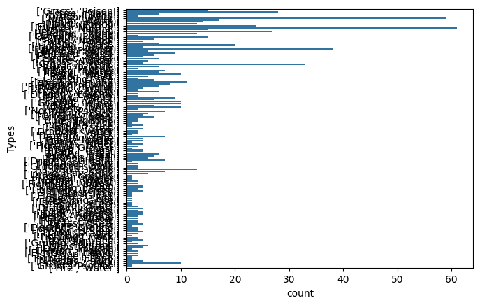

```python
sns.countplot(df, y='Types');
```

```python
# Check if there are any pokemon with only one type
singleton_classes = df['Types'].value_counts()[df['Types'].value_counts() == 1].index.tolist()
singleton_data = df[df['Types'].isin(singleton_classes)]
other_data = df[~df['Types'].isin(singleton_classes)]


print("Number of singleton classes",len(singleton_classes))
print("number of unique type combinations",len(df['Types'].unique()))
#print(len(df['Types']))
df.head()
```

```
Number of singleton classes 24
number of unique type combinations 133
```

|  | Total | HP | Attack | Defense | Sp. Atk | Sp. Def | Speed | Generation | Legendary | Types |
| --- | --- | --- | --- | --- | --- | --- | --- | --- | --- | --- |
| 0 | 318 | 45 | 49 | 49 | 65 | 65 | 45 | 1 | 0 | ['Grass', 'Poison'] |
| 1 | 405 | 60 | 62 | 63 | 80 | 80 | 60 | 1 | 0 | ['Grass', 'Poison'] |
| 2 | 525 | 80 | 82 | 83 | 100 | 100 | 80 | 1 | 0 | ['Grass', 'Poison'] |
| 3 | 625 | 80 | 100 | 123 | 122 | 120 | 80 | 1 | 0 | ['Grass', 'Poison'] |
| 4 | 309 | 39 | 52 | 43 | 60 | 50 | 65 | 1 | 0 | ['Fire', 'None'] |

### Decision tree

```python
# Split the data into training and testing sets
X = df.drop(columns=['Types'])
y = df['Types']

X_train, X_test, y_train, y_test = train_test_split(other_data.drop(columns=['Types']), other_data['Types'], test_size=0.2, stratify=other_data['Types'], random_state=42)
X_train = pd.concat([X_train, singleton_data.drop(columns=['Types'])])
y_train = pd.concat([y_train, singleton_data['Types']])
X_test = pd.concat([X_test, singleton_data.drop(columns=['Types'])])
y_test = pd.concat([y_test, singleton_data['Types']])


# Initialize and train the decision tree classifier
model = DecisionTreeClassifier(random_state=42)
model.fit(X_train, y_train)

# Predict labels for the test set
y_pred = model.predict(X_test)

# Calculate accuracy
print("Score: ", model.score(X_test, y_test))

accuracy = accuracy_score(y_test, y_pred)
print("Accuracy:", accuracy)
```

```
Score:  0.2111111111111111
Accuracy: 0.2111111111111111
```

#### Hyperparameter tuning

```python
# Setup the parameters and distributions to sample from: param_dist
pipeline = make_pipeline(StandardScaler(), DecisionTreeClassifier())

param_dist = {
    "decisiontreeclassifier__max_depth": np.arange(5, 15),
    "decisiontreeclassifier__min_samples_leaf": np.arange(1, 10)
}

# Instantiate the GridSearchCV object
grid_search_cv = GridSearchCV(pipeline, param_grid=param_dist, cv=5)

# Fit grid_search_cv using the data X and labels y.
grid_search_cv.fit(X_train, y_train)
y_pred = grid_search_cv.predict(X_test)

# Print the best score
print("Tuned Model Parameters: {}".format(grid_search_cv.best_params_))
print("Accuracy: {}".format(grid_search_cv.best_estimator_.score(X_test, y_test)))
```

```
Tuned Model Parameters: {'decisiontreeclassifier__max_depth': 5, 'decisiontreeclassifier__min_samples_leaf': 8}
Accuracy: 0.07777777777777778
```

### Random forest

```python
from sklearn.ensemble import RandomForestClassifier

model = RandomForestClassifier(random_state=42)

model.fit(X_train, y_train)

# Predict labels for the test set
y_pred = model.predict(X_test)

# Calculate accuracy
print("Score: ", model.score(X_test, y_test))

accuracy = accuracy_score(y_test, y_pred)
print("Accuracy:", accuracy)
```

```
Score:  0.2388888888888889
Accuracy: 0.2388888888888889
```

#### Hyperparameter Tuning

There's an issue with cross-validation because some type combinations occur only once in the training data.

```python
pipeline = make_pipeline(StandardScaler(), RandomForestClassifier())

# Setup the parameters and distributions to sample from: param_dist
param_dist = {
    "randomforestclassifier__max_depth": np.arange(5, 15),
    "randomforestclassifier__min_samples_leaf": np.arange(1, 10),
    "randomforestclassifier__n_estimators": np.arange(60, 140)
}

random_search_cv = RandomizedSearchCV(pipeline, param_distributions=param_dist, n_iter=100, cv=3, random_state=42)
#grid_search_cv = GridSearchCV(pipeline, param_grid=param_dist, cv=3)

# Fit random_search_cv using the data X and labels y
random_search_cv.fit(X_train, y_train)
#grid_search_cv.fit(X_train, y_train)

# Print the best score
print("Best score is {}".format(random_search_cv.best_estimator_.score(X_test, y_test)))
print("Best parameters are {}".format(random_search_cv.best_params_))
```

```
Best score is 0.25555555555555554
Best parameters are {'randomforestclassifier__n_estimators': 77, 'randomforestclassifier__min_samples_leaf': 1, 'randomforestclassifier__max_depth': 8}
```

### Support vector machine

#### Radial base function

```python
from sklearn.svm import SVC

model = SVC(kernel='rbf', random_state=42)

model.fit(X_train, y_train)
y_pred = model.predict(X_test)

# Calculate accuracy
accuracy = accuracy_score(y_test, y_pred)
print("Accuracy:", accuracy)
```

```
Accuracy: 0.07777777777777778
```

##### Hyperparameter Tuning

```python
from sklearn.svm import SVC

# Define the pipeline with StandardScaler and SVC
pipeline = make_pipeline(StandardScaler(), SVC(kernel='rbf'))

# Define the parameter grid
param_grid = {
    'svc__C': [0.1,0.5, 1,5, 10],        # Regularization parameter
    'svc__coef0': [0.0, 1.0, 2.0], # Independent term in the polynomial kernel function
}

# Initialize GridSearchCV
grid_search = GridSearchCV(pipeline, param_grid, cv=5, n_jobs=-1)

# Perform grid search
grid_search.fit(X_train, y_train)

# Get the best parameters and score
best_params = grid_search.best_params_
best_score = grid_search.best_estimator_.score(X_test, y_test)

print("Best Parameters:", best_params)
print("Best Score:", best_score)
```

```
Best Parameters: {'svc__C': 5, 'svc__coef0': 0.0}
Best Score: 0.18888888888888888
```

#### Linear

```python
svm_classifier = SVC(kernel='linear', random_state=42)

# Train the SVM classifier
svm_classifier.fit(X_train, y_train)
y_pred = svm_classifier.predict(X_test)

# Calculate accuracy
accuracy = accuracy_score(y_test, y_pred)
print("Accuracy:", accuracy)
```

```
Accuracy: 0.23333333333333334
```

##### Hyperparameter tuning

```python
from sklearn.svm import SVC

# Define the pipeline with StandardScaler and SVC
pipeline = make_pipeline(StandardScaler(), SVC(kernel='linear'))

# Define the parameter grid
param_grid = {
    'svc__C': [0.1,0.5, 1 , 5, 10],        # Regularization parameter    # Degree of the polynomial kernel
    'svc__coef0': [0.0, 1.0, 2.0], # Independent term in the polynomial kernel function
}

# Initialize GridSearchCV
grid_search = GridSearchCV(pipeline, param_grid, cv=5, n_jobs=-1)

# Perform grid search
grid_search.fit(X_train, y_train)

# Get the best parameters and score
best_params = grid_search.best_params_
best_score = grid_search.best_estimator_.score(X_test, y_test)

print("Best Parameters:", best_params)
print("Best Score:", best_score)
```

```
Best Parameters: {'svc__C': 1, 'svc__coef0': 0.0}
Best Score: 0.21666666666666667
```

#### Polynomial

```python
model = SVC(kernel='poly', random_state=42)

# Train the SVM classifier
model.fit(X_train, y_train)
y_pred = model.predict(X_test)

# Calculate accuracy
accuracy = accuracy_score(y_test, y_pred)
print("Accuracy:", accuracy)
```

```
Accuracy: 0.06666666666666667
```

##### Hyperparameter Tuning

```python
from sklearn.svm import SVC

# Define the pipeline with StandardScaler and SVC
pipeline = make_pipeline(StandardScaler(), SVC(kernel='poly'))

# Define the parameter grid
param_grid = {
    'svc__C': [0.1,0.5, 1,5, 10],        # Regularization parameter
    'svc__degree': [2, 3, 4, 5, 6],      # Degree of the polynomial kernel
    'svc__coef0': [0.0, 1.0, 2.0], # Independent term in the polynomial kernel function
}

# Initialize GridSearchCV
grid_search = GridSearchCV(pipeline, param_grid, cv=5, n_jobs=-1)

# Perform grid search
grid_search.fit(X_train, y_train)

# Get the best parameters and score
best_params = grid_search.best_params_
best_score = grid_search.best_estimator_.score(X_test, y_test)

print("Best Parameters:", best_params)
print("Best Score:", best_score)
```

```
Best Parameters: {'svc__C': 1, 'svc__coef0': 1.0, 'svc__degree': 3}
Best Score: 0.2222222222222222
```

#### Sigmoid

```python
model = SVC(kernel='sigmoid', random_state=42)

# Train the SVM classifier
model.fit(X_train, y_train)
y_pred = model.predict(X_test)

# Calculate accuracy
print("Score: ", model.score(X_test, y_test))

accuracy = accuracy_score(y_test, y_pred)
print("Accuracy:", accuracy)
```

```
Score:  0.03888888888888889
Accuracy: 0.03888888888888889
```

##### Hyperparameter Tuning

```python
from sklearn.svm import SVC

# Define the pipeline with StandardScaler and SVC
pipeline = make_pipeline(StandardScaler(), SVC(kernel='sigmoid'))

# Define the parameter grid
param_grid = {
    'svc__C': [0.1,0.5, 1,5, 10, 50],        # Regularization parameter
    'svc__coef0': [0.0, 1.0, 2.0], # Independent term in the polynomial kernel function
}

# Initialize GridSearchCV
grid_search = GridSearchCV(pipeline, param_grid, cv=5, n_jobs=-1)

# Perform grid search
grid_search.fit(X_train, y_train)

# Get the best parameters and score
best_params = grid_search.best_params_
best_score = grid_search.best_estimator_.score(X_test, y_test)

print("Best Parameters:", best_params)
print("Best Score:", best_score)
```

```
Best Parameters: {'svc__C': 5, 'svc__coef0': 0.0}
Best Score: 0.11666666666666667
```

### k Nearest Neighbors

```python
from sklearn.neighbors import KNeighborsClassifier
model = KNeighborsClassifier()
model.fit(X_train, y_train)

y_pred = model.predict(X_test)

# Calculate accuracy
print("Score: ", model.score(X_test, y_test))

accuracy = accuracy_score(y_test, y_pred)
print("Accuracy:", accuracy)
```

```
Score:  0.11666666666666667
Accuracy: 0.11666666666666667
```

#### Hyperparameter Tuning

```python
param_grid = {
    'kneighborsclassifier__n_neighbors': [3, 5, 7, 9]  # List of k values to try
}

pipeline = make_pipeline(StandardScaler(), KNeighborsClassifier())

grid_search = GridSearchCV(estimator=pipeline, param_grid=param_grid, cv=5)

grid_search.fit(X_train, y_train)

best_params = grid_search.best_params_
best_score=grid_search.best_estimator_.score(X_test, y_test)

print("Best Parameters:", best_params)
print("Best Score:", best_score)
```

```
Best Parameters: {'kneighborsclassifier__n_neighbors': 9}
Best Score: 0.10555555555555556
```

### Logistic regression

```python
model = LogisticRegression()
model.fit(X_train, y_train)

y_pred = model.predict(X_test)

# Calculate accuracy
print("Score: ", model.score(X_test, y_test))

accuracy = accuracy_score(y_test, y_pred)
print("Accuracy:", accuracy)
```

```
Score:  0.1388888888888889
Accuracy: 0.1388888888888889
```

```python
from sklearn.linear_model import LogisticRegression
model = LogisticRegression( random_state=42, multi_class='auto', solver='liblinear', max_iter=1000)
model.fit(X_train, y_train)

y_pred = model.predict(X_test)

# Calculate accuracy
print("Score: ", model.score(X_test, y_test))

accuracy = accuracy_score(y_test, y_pred)
print("Accuracy:", accuracy)
```

```
Score:  0.16111111111111112
Accuracy: 0.16111111111111112
```

#### Hyperparameter tuning

```python
param_grid = {
    'logisticregression__C': np.logspace(-5, 5, 5),
    'logisticregression__penalty': ['l1', 'l2']
}

pipeline = make_pipeline(StandardScaler(), LogisticRegression(solver='liblinear'))

grid_search = GridSearchCV(estimator=pipeline, param_grid=param_grid, cv=5)

grid_search.fit(X_train, y_train)

best_params = grid_search.best_params_
best_score=grid_search.best_estimator_.score(X_test, y_test)

print("Best Parameters:", best_params)
print("Best Score:", best_score)
```

```
Best Parameters: {'logisticregression__C': 316.22776601683796, 'logisticregression__penalty': 'l2'}
Best Score: 0.2111111111111111
```

```python
from sklearn.linear_model import LogisticRegression
model = LogisticRegression( penalty='elasticnet',l1_ratio=0.5, random_state=42, multi_class='auto', solver='saga', max_iter=1000)
model.fit(X_train, y_train)

y_pred = model.predict(X_test)

# Calculate accuracy
print("Score: ", model.score(X_test, y_test))

accuracy = accuracy_score(y_test, y_pred)
print("Accuracy:", accuracy)
```

```
Score:  0.17222222222222222
Accuracy: 0.17222222222222222
```

#### Hyperparameter tuning

```python
param_grid = {
    'logisticregression__C': np.logspace(-5, 5, 5),
    'logisticregression__l1_ratio': np.linspace(0, 1, 10)
}

pipeline = make_pipeline(StandardScaler(), LogisticRegression(penalty='elasticnet', solver='saga'))

grid_search = GridSearchCV(estimator=pipeline, param_grid=param_grid, cv=5)

grid_search.fit(X_train, y_train)

best_params = grid_search.best_params_
best_score=grid_search.best_estimator_.score(X_test, y_test)

print("Best Parameters:", best_params)
print("Best Score:", best_score)
```

[output not shown]

[output cut: 257 more lines]

[output not shown]

```
Best Parameters: {'logisticregression__C': 1.0, 'logisticregression__l1_ratio': 0.0}
Best Score: 0.15
```

# Multi-label Classification

## Accounting for Order of Types

### Preprocessing

```python
df = preprocessed_df.copy()

df['Types'] = df[['Type 1', 'Type 2']].apply(lambda x: tuple(filter(lambda y: pd.notna(y), x)), axis=1)
df.Types = df.Types.astype(str)

# print two pokemon types where we know type 1 and two are the same but reversed to check if order is kept into account
print("Sableye: ",df['Types'][326])
print("Spiritomb: ",df['Types'][490])

# drop the Type 1 and Type 2 columns
df.drop(['Type 1', 'Type 2'], axis=1, inplace=True)

# print head
df.head()
```

```
Sableye:  ('Dark', 'Ghost')
Spiritomb:  ('Ghost', 'Dark')
```

|  | Total | HP | Attack | Defense | Sp. Atk | Sp. Def | Speed | Generation | Legendary | Types |
| --- | --- | --- | --- | --- | --- | --- | --- | --- | --- | --- |
| 0 | 318 | 45 | 49 | 49 | 65 | 65 | 45 | 1 | 0 | ('Grass', 'Poison') |
| 1 | 405 | 60 | 62 | 63 | 80 | 80 | 60 | 1 | 0 | ('Grass', 'Poison') |
| 2 | 525 | 80 | 82 | 83 | 100 | 100 | 80 | 1 | 0 | ('Grass', 'Poison') |
| 3 | 625 | 80 | 100 | 123 | 122 | 120 | 80 | 1 | 0 | ('Grass', 'Poison') |
| 4 | 309 | 39 | 52 | 43 | 60 | 50 | 65 | 1 | 0 | ('Fire', 'None') |

```python
# Find classes with only one type
singleton_classes = df['Types'].value_counts()[df['Types'].value_counts() == 1].index.tolist()
```

To account for order of types, we create binary labels for each type combination.

```python
# Create binary labels for each Pokémon type combination
type_combinations = df['Types'].unique()
for type in type_combinations:
    df[type] = df['Types'].apply(lambda x: 1 if type in x else 0)

singleton_data = df[df['Types'].isin(singleton_classes)]
other_data = df[~df['Types'].isin(singleton_classes)]

print("Number of singleton classes",len(singleton_classes))
print("Number of unique type combinations",len(df['Types'].unique()))
print(len(df['Types']))
df.head()
```

[output not shown]

[output cut: 88 more lines]

```
Number of singleton classes 39
Number of unique type combinations 154
800
```

|  | Total | HP | Attack | Defense | Sp. Atk | Sp. Def | Speed | Generation | Legendary | Types | ... | ('Rock', 'Dragon') | ('Rock', 'Ice') | ('Fighting', 'Flying') | ('Electric', 'Fairy') | ('Rock', 'Fairy') | ('Ghost', 'Grass') | ('Flying', 'Dragon') | ('Psychic', 'Ghost') | ('Psychic', 'Dark') | ('Fire', 'Water') |
| --- | --- | --- | --- | --- | --- | --- | --- | --- | --- | --- | --- | --- | --- | --- | --- | --- | --- | --- | --- | --- | --- |
| 0 | 318 | 45 | 49 | 49 | 65 | 65 | 45 | 1 | 0 | ('Grass', 'Poison') | ... | 0 | 0 | 0 | 0 | 0 | 0 | 0 | 0 | 0 | 0 |
| 1 | 405 | 60 | 62 | 63 | 80 | 80 | 60 | 1 | 0 | ('Grass', 'Poison') | ... | 0 | 0 | 0 | 0 | 0 | 0 | 0 | 0 | 0 | 0 |
| 2 | 525 | 80 | 82 | 83 | 100 | 100 | 80 | 1 | 0 | ('Grass', 'Poison') | ... | 0 | 0 | 0 | 0 | 0 | 0 | 0 | 0 | 0 | 0 |
| 3 | 625 | 80 | 100 | 123 | 122 | 120 | 80 | 1 | 0 | ('Grass', 'Poison') | ... | 0 | 0 | 0 | 0 | 0 | 0 | 0 | 0 | 0 | 0 |
| 4 | 309 | 39 | 52 | 43 | 60 | 50 | 65 | 1 | 0 | ('Fire', 'None') | ... | 0 | 0 | 0 | 0 | 0 | 0 | 0 | 0 | 0 | 0 |

5 rows × 164 columns

```python
# Drop the 'Types' column
df = df.drop(columns=['Types'])
other_data.drop(columns=['Types'], inplace=True)
singleton_data.drop(columns=['Types'], inplace=True)
```

### Decision Tree

```python
from sklearn.metrics import classification_report
# Split the data into training and testing sets
y = df[type_combinations]

X_train, X_test, y_train, y_test = train_test_split(other_data.drop(columns=type_combinations), other_data[type_combinations], test_size=0.2, stratify=other_data[type_combinations], random_state=42)
X_train = pd.concat([X_train, singleton_data.drop(columns=type_combinations)])
y_train = pd.concat([y_train, singleton_data[type_combinations]])
X_test = pd.concat([X_test, singleton_data.drop(columns=type_combinations)])
y_test = pd.concat([y_test, singleton_data[type_combinations]])


# Initialize and train the decision tree classifier
model = DecisionTreeClassifier(random_state=42)
model.fit(X_train, y_train)

# Predict labels for the test set
y_pred = model.predict(X_test)
score = model.score(X_test, y_test)

# Calculate accuracy
print("Score: ", score)
accuracy = accuracy_score(y_test, y_pred)
print("Accuracy: ", accuracy)
print(classification_report(y_test, y_pred))
```

```
Score:  0.25
Accuracy:  0.25
              precision    recall  f1-score   support

           0       0.20      0.33      0.25         3
           1       0.00      0.00      0.00         6
           2       0.00      0.00      0.00         1
           3       1.00      1.00      1.00         1
           4       0.07      0.08      0.08        12
           5       0.00      0.00      0.00         4
           6       0.00      0.00      0.00         3
           7       0.33      0.33      0.33         3
           8       0.17      0.20      0.18         5
           9       0.12      0.17      0.14        12
          10       0.00      0.00      0.00         3
```

[output cut: 148 more lines]

#### Hyperparameter tuning

```python
pipeline = make_pipeline(StandardScaler(), DecisionTreeClassifier())

# Setup the parameters
param_dist = {
    "decisiontreeclassifier__max_depth": [5, 6, 7, 8, 9, 10, 15, 30, None],
    "decisiontreeclassifier__min_samples_leaf": np.arange(1, 10)
}

# Instantiate the GridSearchCV object
grid_search_cv = GridSearchCV(pipeline, param_grid=param_dist, cv=5)

# Fit grid_search_cv using the data X and labels y.
grid_search_cv.fit(X_train, y_train)
y_pred = grid_search_cv.predict(X_test)

# Print the best score
print("Tuned Model Parameters: {}".format(grid_search_cv.best_params_))
print("Accuracy: {}".format(grid_search_cv.best_estimator_.score(X_test, y_test)))
print(classification_report(y_test, y_pred))
```

```
Tuned Model Parameters: {'decisiontreeclassifier__max_depth': 30, 'decisiontreeclassifier__min_samples_leaf': 1}
Accuracy: 0.2552083333333333
              precision    recall  f1-score   support

           0       0.20      0.33      0.25         3
           1       0.00      0.00      0.00         6
           2       0.00      0.00      0.00         1
           3       1.00      1.00      1.00         1
           4       0.07      0.08      0.08        12
           5       0.00      0.00      0.00         4
           6       0.00      0.00      0.00         3
           7       0.50      0.33      0.40         3
           8       0.25      0.40      0.31         5
           9       0.06      0.08      0.07        12
          10       0.00      0.00      0.00         3
```

[output cut: 148 more lines]

### Random Forest

```python
from sklearn.ensemble import RandomForestClassifier

model = RandomForestClassifier(random_state=42)

model.fit(X_train, y_train)

# Predict labels for the test set
y_pred = model.predict(X_test)
score = model.score(X_test, y_test)
# Calculate accuracy
print("Score: ", score)
accuracy = accuracy_score(y_test, y_pred)
print("Accuracy:", accuracy)
print(classification_report(y_test, y_pred))
```

```
Score:  0.203125
Accuracy: 0.203125
              precision    recall  f1-score   support

           0       0.00      0.00      0.00         3
           1       0.00      0.00      0.00         6
           2       0.00      0.00      0.00         1
           3       1.00      1.00      1.00         1
           4       0.00      0.00      0.00        12
           5       0.00      0.00      0.00         4
           6       0.00      0.00      0.00         3
           7       0.00      0.00      0.00         3
           8       0.00      0.00      0.00         5
           9       0.00      0.00      0.00        12
          10       0.00      0.00      0.00         3
```

[output cut: 148 more lines]

### Hyperparameter Tuning

```python
pipeline = make_pipeline(StandardScaler(), RandomForestClassifier())

# Setup the parameters and distributions to sample from: param_dist
param_dist = {
    "randomforestclassifier__max_depth": [5, 15, 30, None],
    "randomforestclassifier__min_samples_leaf": np.arange(1, 10, 3),
    "randomforestclassifier__n_estimators": np.arange(60, 140, 20)
}

random_search_cv = RandomizedSearchCV(pipeline, param_distributions=param_dist, n_iter=75, cv=3, random_state=42)
#grid_search_cv = GridSearchCV(pipeline, param_grid=param_dist, cv=3)

# Fit random_search_cv using the data X and labels y
random_search_cv.fit(X_train, y_train)
#grid_search_cv.fit(X_train, y_train)

# Print the best score
print("Best score is {}".format(random_search_cv.best_estimator_.score(X_test, y_test)))
print("Best parameters are {}".format(random_search_cv.best_params_))
print(classification_report(y_test, y_pred))
```

```
Best score is 0.203125
Best parameters are {'randomforestclassifier__n_estimators': 120, 'randomforestclassifier__min_samples_leaf': 1, 'randomforestclassifier__max_depth': 30}
              precision    recall  f1-score   support

           0       0.00      0.00      0.00         3
           1       0.00      0.00      0.00         6
           2       0.00      0.00      0.00         1
           3       1.00      1.00      1.00         1
           4       0.00      0.00      0.00        12
           5       0.00      0.00      0.00         4
           6       0.00      0.00      0.00         3
           7       0.00      0.00      0.00         3
           8       0.00      0.00      0.00         5
           9       0.00      0.00      0.00        12
          10       0.00      0.00      0.00         3
```

[output cut: 148 more lines]

### K Nearest neighbors

```python
from sklearn.neighbors import KNeighborsClassifier
model = KNeighborsClassifier()
model.fit(X_train, y_train)

y_pred = model.predict(X_test)

# Calculate accuracy
print("Score: ", model.score(X_test, y_test))
accuracy = accuracy_score(y_test, y_pred)
print("Accuracy:", accuracy)
print(classification_report(y_test, y_pred))
```

```
Score:  0.010416666666666666
Accuracy: 0.010416666666666666
              precision    recall  f1-score   support

           0       0.00      0.00      0.00         3
           1       0.00      0.00      0.00         6
           2       0.00      0.00      0.00         1
           3       0.00      0.00      0.00         1
           4       0.00      0.00      0.00        12
           5       0.00      0.00      0.00         4
           6       0.00      0.00      0.00         3
           7       0.00      0.00      0.00         3
           8       1.00      0.20      0.33         5
           9       0.00      0.00      0.00        12
          10       0.00      0.00      0.00         3
```

[output cut: 148 more lines]

#### Hyperparameter Tuning

```python
param_grid = {
    'kneighborsclassifier__n_neighbors': [3, 5, 7, 9]  # List of k values to try
}

pipeline = make_pipeline(StandardScaler(), KNeighborsClassifier())

grid_search = GridSearchCV(estimator=pipeline, param_grid=param_grid, cv=5)

grid_search.fit(X_train, y_train)

best_params = grid_search.best_params_
best_score=grid_search.best_estimator_.score(X_test, y_test)

print("Best Parameters:", best_params)
print("Best Score:", best_score)
print(classification_report(y_test, y_pred))
```

```
Best Parameters: {'kneighborsclassifier__n_neighbors': 3}
Best Score: 0.036458333333333336
              precision    recall  f1-score   support

           0       0.00      0.00      0.00         3
           1       0.00      0.00      0.00         6
           2       0.00      0.00      0.00         1
           3       0.00      0.00      0.00         1
           4       0.00      0.00      0.00        12
           5       0.00      0.00      0.00         4
           6       0.00      0.00      0.00         3
           7       0.00      0.00      0.00         3
           8       1.00      0.20      0.33         5
           9       0.00      0.00      0.00        12
          10       0.00      0.00      0.00         3
```

[output cut: 148 more lines]

## Ignoring Order of Types 1

The first way to ignore order of types is by making a label for each type and matching the data with two labels .

### Preprocessing

```python
df  = preprocessed_df.copy()

# Combine Type 1 and Type 2 into a single column
df['Types'] = df[['Type 1', 'Type 2']].apply(lambda x: tuple(filter(lambda y: pd.notna(y), x)), axis=1)
print(df['Types'][0])

# Get unique Pokémon types
unique_types = np.unique(df['Types'].explode())
df.drop(['Type 1', 'Type 2'], axis=1, inplace=True)

df.head()
```

```
('Grass', 'Poison')
```

|  | Total | HP | Attack | Defense | Sp. Atk | Sp. Def | Speed | Generation | Legendary | Types |
| --- | --- | --- | --- | --- | --- | --- | --- | --- | --- | --- |
| 0 | 318 | 45 | 49 | 49 | 65 | 65 | 45 | 1 | 0 | (Grass, Poison) |
| 1 | 405 | 60 | 62 | 63 | 80 | 80 | 60 | 1 | 0 | (Grass, Poison) |
| 2 | 525 | 80 | 82 | 83 | 100 | 100 | 80 | 1 | 0 | (Grass, Poison) |
| 3 | 625 | 80 | 100 | 123 | 122 | 120 | 80 | 1 | 0 | (Grass, Poison) |
| 4 | 309 | 39 | 52 | 43 | 60 | 50 | 65 | 1 | 0 | (Fire, None) |

For each unique type, we create a binary label. The label is 1 if the Pokemon has that type, (so was present in the type combination tuple) and 0 if it doesn't.

```python
# Create binary labels for each Pokémon type
for type in unique_types:
    df[type] = df['Types'].apply(lambda x: 1 if type in x else 0)

df.head()
```

|  | Total | HP | Attack | Defense | Sp. Atk | Sp. Def | Speed | Generation | Legendary | Types | ... | Grass | Ground | Ice | None | Normal | Poison | Psychic | Rock | Steel | Water |
| --- | --- | --- | --- | --- | --- | --- | --- | --- | --- | --- | --- | --- | --- | --- | --- | --- | --- | --- | --- | --- | --- |
| 0 | 318 | 45 | 49 | 49 | 65 | 65 | 45 | 1 | 0 | (Grass, Poison) | ... | 1 | 0 | 0 | 0 | 0 | 1 | 0 | 0 | 0 | 0 |
| 1 | 405 | 60 | 62 | 63 | 80 | 80 | 60 | 1 | 0 | (Grass, Poison) | ... | 1 | 0 | 0 | 0 | 0 | 1 | 0 | 0 | 0 | 0 |
| 2 | 525 | 80 | 82 | 83 | 100 | 100 | 80 | 1 | 0 | (Grass, Poison) | ... | 1 | 0 | 0 | 0 | 0 | 1 | 0 | 0 | 0 | 0 |
| 3 | 625 | 80 | 100 | 123 | 122 | 120 | 80 | 1 | 0 | (Grass, Poison) | ... | 1 | 0 | 0 | 0 | 0 | 1 | 0 | 0 | 0 | 0 |
| 4 | 309 | 39 | 52 | 43 | 60 | 50 | 65 | 1 | 0 | (Fire, None) | ... | 0 | 0 | 0 | 1 | 0 | 0 | 0 | 0 | 0 | 0 |

5 rows × 29 columns

```python
# Some type combinations only occur once so we double them to stratify the data better
singleton_classes = df['Types'].value_counts()[df['Types'].value_counts() == 1].index.tolist()
singleton_data = df[df['Types'].isin(singleton_classes)]
other_data = df[~df['Types'].isin(singleton_classes)]

df = df.drop(columns=['Types'])
other_data.drop(columns=['Types'], inplace=True)
singleton_data.drop(columns=['Types'], inplace=True)
```

### Decision tree

```python
# Split the data into training and testing sets
y = df[unique_types]
X_train, X_test, y_train, y_test = train_test_split(other_data.drop(columns=unique_types), other_data[unique_types], test_size=0.2, stratify=other_data[unique_types], random_state=42)
X_train = pd.concat([X_train, singleton_data.drop(columns=unique_types)])
y_train = pd.concat([y_train, singleton_data[unique_types]])
X_test = pd.concat([X_test, singleton_data.drop(columns=unique_types)])
y_test = pd.concat([y_test, singleton_data[unique_types]])

# Initialize and train the decision tree classifier
model = DecisionTreeClassifier(random_state=42)
model.fit(X_train, y_train)

# Predict labels for the test set
y_pred = model.predict(X_test)

# Calculate accuracy
accuracy = accuracy_score(y_test, y_pred)
print("Score: ", model.score(X_test, y_test))
print("Accuracy:", accuracy)
print(classification_report(y_test, y_pred))
```

```
Score:  0.25
Accuracy: 0.25
              precision    recall  f1-score   support

           0       0.47      0.47      0.47        17
           1       0.56      0.42      0.48        12
           2       0.44      0.47      0.46        17
           3       0.65      0.65      0.65        17
           4       0.38      0.30      0.33        10
           5       0.40      0.31      0.35        13
           6       0.53      0.45      0.49        20
           7       0.27      0.35      0.30        23
           8       0.50      0.50      0.50        12
           9       0.24      0.27      0.26        22
          10       0.43      0.50      0.46        18
          11       0.17      0.22      0.19         9
          12       0.57      0.49      0.53        80
          13       0.27      0.33      0.30        21
          14       0.23      0.19      0.21        16
          15       0.44      0.40      0.42        20
          16       0.60      0.50      0.55        12
          17       0.56      0.60      0.58        15
          18       0.29      0.30      0.30        30

   micro avg       0.42      0.42      0.42       384
   macro avg       0.42      0.41      0.41       384
weighted avg       0.44      0.42      0.42       384
 samples avg       0.43      0.42      0.42       384
```

#### Hyperparameter tuning

```python
pipeline = make_pipeline(StandardScaler(), DecisionTreeClassifier())

param_dist = {
    "decisiontreeclassifier__max_depth": np.arange(10, 20),
    "decisiontreeclassifier__min_samples_leaf": np.arange(1, 10)
}

# Instantiate the GridSearchCV object
grid_search_cv = GridSearchCV(pipeline, param_grid=param_dist, cv=5)

# Fit grid_search_cv using the data X and labels y.
grid_search_cv.fit(X_train, y_train)
y_pred = grid_search_cv.predict(X_test)

# Print the best score
print("Tuned Model Parameters: {}".format(grid_search_cv.best_params_))
print("Accuracy: {}".format(grid_search_cv.best_estimator_.score(X_test, y_test)))
print(classification_report(y_test, y_pred))
```

```
Tuned Model Parameters: {'decisiontreeclassifier__max_depth': 16, 'decisiontreeclassifier__min_samples_leaf': 1}
Accuracy: 0.265625
              precision    recall  f1-score   support

           0       0.42      0.47      0.44        17
           1       0.50      0.50      0.50        12
           2       0.38      0.47      0.42        17
           3       0.52      0.65      0.58        17
           4       0.30      0.30      0.30        10
           5       0.50      0.38      0.43        13
           6       0.67      0.40      0.50        20
           7       0.38      0.35      0.36        23
           8       0.60      0.50      0.55        12
           9       0.29      0.27      0.28        22
          10       0.45      0.50      0.47        18
          11       0.17      0.22      0.19         9
          12       0.61      0.57      0.59        80
          13       0.27      0.29      0.28        21
          14       0.27      0.25      0.26        16
          15       0.50      0.40      0.44        20
          16       0.45      0.42      0.43        12
          17       0.62      0.53      0.57        15
          18       0.31      0.37      0.34        30

   micro avg       0.45      0.44      0.44       384
   macro avg       0.43      0.41      0.42       384
weighted avg       0.46      0.44      0.44       384
 samples avg       0.45      0.44      0.44       384
```

### Random Forest

```python
from sklearn.ensemble import RandomForestClassifier

model = RandomForestClassifier(random_state=42)

model.fit(X_train, y_train)

# Predict labels for the test set
y_pred = model.predict(X_test)

# Calculate accuracy
print("Score: ", model.score(X_test, y_test))
accuracy = accuracy_score(y_test, y_pred)
print("Accuracy:", accuracy)
print(classification_report(y_test, y_pred))
```

```
Score:  0.20833333333333334
Accuracy: 0.20833333333333334
              precision    recall  f1-score   support

           0       1.00      0.29      0.45        17
           1       1.00      0.25      0.40        12
           2       0.69      0.53      0.60        17
           3       1.00      0.59      0.74        17
           4       1.00      0.20      0.33        10
           5       1.00      0.31      0.47        13
           6       1.00      0.45      0.62        20
           7       0.50      0.09      0.15        23
           8       0.86      0.50      0.63        12
           9       0.67      0.18      0.29        22
          10       1.00      0.28      0.43        18
          11       1.00      0.11      0.20         9
          12       0.65      0.49      0.56        80
          13       0.43      0.14      0.21        21
          14       0.75      0.19      0.30        16
          15       0.83      0.25      0.38        20
          16       0.80      0.33      0.47        12
          17       0.86      0.40      0.55        15
          18       1.00      0.17      0.29        30

   micro avg       0.77      0.33      0.46       384
   macro avg       0.84      0.30      0.43       384
weighted avg       0.80      0.33      0.44       384
 samples avg       0.44      0.33      0.36       384
```

#### Hyperparameter tuning

```python
from sklearn.model_selection import RandomizedSearchCV
from scipy.stats import randint
# Define the parameter grid
pipeline = make_pipeline(StandardScaler(), RandomForestClassifier())

# Setup the parameters and distributions to sample from: param_dist
param_dist = {
    "randomforestclassifier__max_depth": np.arange(10, 20),
    "randomforestclassifier__min_samples_leaf": np.arange(1, 10, 4),
    "randomforestclassifier__n_estimators": np.arange(60, 140, 5)
}

random_search_cv = RandomizedSearchCV(pipeline, param_distributions=param_dist, n_iter=50, cv=3, random_state=42)
#grid_search_cv = GridSearchCV(pipeline, param_grid=param_dist, cv=3)

# Fit random_search_cv using the data X and labels y
random_search_cv.fit(X_train, y_train)
#grid_search_cv.fit(X_train, y_train)

# Print the best score
print("Best score is {}".format(random_search_cv.best_estimator_.score(X_test, y_test)))
print("Best parameters are {}".format(random_search_cv.best_params_))

#print("Best score is {}".format(grid_search_cv.best_estimator_.score(X_test, y_test)))
#print("Best parameters are {}".format(grid_search_cv.best_params_))
print(classification_report(y_test, y_pred))
```

```
Best score is 0.203125
Best parameters are {'randomforestclassifier__n_estimators': 130, 'randomforestclassifier__min_samples_leaf': 1, 'randomforestclassifier__max_depth': 16}
              precision    recall  f1-score   support

           0       1.00      0.29      0.45        17
           1       1.00      0.25      0.40        12
           2       0.69      0.53      0.60        17
           3       1.00      0.59      0.74        17
           4       1.00      0.20      0.33        10
           5       1.00      0.31      0.47        13
           6       1.00      0.45      0.62        20
           7       0.50      0.09      0.15        23
           8       0.86      0.50      0.63        12
           9       0.67      0.18      0.29        22
          10       1.00      0.28      0.43        18
          11       1.00      0.11      0.20         9
          12       0.65      0.49      0.56        80
          13       0.43      0.14      0.21        21
          14       0.75      0.19      0.30        16
          15       0.83      0.25      0.38        20
          16       0.80      0.33      0.47        12
          17       0.86      0.40      0.55        15
          18       1.00      0.17      0.29        30

   micro avg       0.77      0.33      0.46       384
   macro avg       0.84      0.30      0.43       384
weighted avg       0.80      0.33      0.44       384
 samples avg       0.44      0.33      0.36       384
```

### K Nearest neigbors

```python
from sklearn.neighbors import KNeighborsClassifier
model = KNeighborsClassifier()
model.fit(X_train, y_train)

y_pred = model.predict(X_test)

# Calculate accuracy
print("Score: ", model.score(X_test, y_test))
accuracy = accuracy_score(y_test, y_pred)
print("Accuracy:", accuracy)
print(classification_report(y_test, y_pred))
```

```
Score:  0.015625
Accuracy: 0.015625
              precision    recall  f1-score   support

           0       0.67      0.12      0.20        17
           1       0.00      0.00      0.00        12
           2       0.36      0.24      0.29        17
           3       0.83      0.29      0.43        17
           4       0.00      0.00      0.00        10
           5       0.00      0.00      0.00        13
           6       0.33      0.10      0.15        20
           7       0.25      0.09      0.13        23
           8       0.33      0.08      0.13        12
           9       0.33      0.05      0.08        22
          10       0.33      0.11      0.17        18
          11       0.00      0.00      0.00         9
          12       0.56      0.50      0.53        80
          13       0.31      0.19      0.24        21
          14       0.00      0.00      0.00        16
          15       0.33      0.15      0.21        20
          16       0.67      0.17      0.27        12
          17       0.33      0.07      0.11        15
          18       0.17      0.03      0.06        30

   micro avg       0.46      0.18      0.26       384
   macro avg       0.31      0.11      0.16       384
weighted avg       0.36      0.18      0.22       384
 samples avg       0.31      0.18      0.22       384
```

#### Hyperparameter tuning

```python
param_grid = {
    'kneighborsclassifier__n_neighbors': [3, 5, 7, 9]  # List of k values to try
}

pipeline = make_pipeline(StandardScaler(), KNeighborsClassifier())

grid_search = GridSearchCV(estimator=pipeline, param_grid=param_grid, cv=5)

grid_search.fit(X_train, y_train)

best_params = grid_search.best_params_
best_score=grid_search.best_estimator_.score(X_test, y_test)

print("Best Parameters:", best_params)
print("Best Score:", best_score)
print(classification_report(y_test, y_pred))
```

```
Best Parameters: {'kneighborsclassifier__n_neighbors': 3}
Best Score: 0.046875
              precision    recall  f1-score   support

           0       0.67      0.12      0.20        17
           1       0.00      0.00      0.00        12
           2       0.36      0.24      0.29        17
           3       0.83      0.29      0.43        17
           4       0.00      0.00      0.00        10
           5       0.00      0.00      0.00        13
           6       0.33      0.10      0.15        20
           7       0.25      0.09      0.13        23
           8       0.33      0.08      0.13        12
           9       0.33      0.05      0.08        22
          10       0.33      0.11      0.17        18
          11       0.00      0.00      0.00         9
          12       0.56      0.50      0.53        80
          13       0.31      0.19      0.24        21
          14       0.00      0.00      0.00        16
          15       0.33      0.15      0.21        20
          16       0.67      0.17      0.27        12
          17       0.33      0.07      0.11        15
          18       0.17      0.03      0.06        30

   micro avg       0.46      0.18      0.26       384
   macro avg       0.31      0.11      0.16       384
weighted avg       0.36      0.18      0.22       384
 samples avg       0.31      0.18      0.22       384
```

## Ignoring Order of Types 2

The second way of ignoring order of types is to use binary labels for each sorted type combination.

### Preprocessing

We again combine the Type 1 and Type 2 columns into a single column that contains a list of type combination tuples that are sorted.

```python
df = preprocessed_df.copy()

df['Types'] = df[['Type 1', 'Type 2']].apply(lambda x: sorted(tuple(filter(lambda y: pd.notna(y), x))), axis=1)

df['Types'] = df['Types'].astype(str)

# print two pokemon types where we know type 1 and two are the same but reversed to check if order is kept into account
print("Sableye: ",df['Types'][326])
print("Spiritomb: ",df['Types'][490])

# drop the Type 1 and Type 2 columns
df.drop(['Type 1', 'Type 2'], axis=1, inplace=True)
# print head
df.head()
```

```
Sableye:  ['Dark', 'Ghost']
Spiritomb:  ['Dark', 'Ghost']
```

|  | Total | HP | Attack | Defense | Sp. Atk | Sp. Def | Speed | Generation | Legendary | Types |
| --- | --- | --- | --- | --- | --- | --- | --- | --- | --- | --- |
| 0 | 318 | 45 | 49 | 49 | 65 | 65 | 45 | 1 | 0 | ['Grass', 'Poison'] |
| 1 | 405 | 60 | 62 | 63 | 80 | 80 | 60 | 1 | 0 | ['Grass', 'Poison'] |
| 2 | 525 | 80 | 82 | 83 | 100 | 100 | 80 | 1 | 0 | ['Grass', 'Poison'] |
| 3 | 625 | 80 | 100 | 123 | 122 | 120 | 80 | 1 | 0 | ['Grass', 'Poison'] |
| 4 | 309 | 39 | 52 | 43 | 60 | 50 | 65 | 1 | 0 | ['Fire', 'None'] |

```python
# Find classes with only one type
singleton_classes = df['Types'].value_counts()[df['Types'].value_counts() == 1].index.tolist()
```

```python
# Create binary labels for each Pokémon type combination
unique_type_combinations = df['Types'].unique()
for type_combination in unique_type_combinations:
    df[type_combination] = df['Types'].apply(lambda x: 1 if type in x else 0)

singleton_data = df[df['Types'].isin(singleton_classes)]
other_data = df[~df['Types'].isin(singleton_classes)]

print("Number of singleton classes",len(singleton_classes))
print("Number of unique type combinations",len(df['Types'].unique()))
print(len(df['Types']))
df.head()
```

```
Number of singleton classes 24
Number of unique type combinations 133
800
```

[output not shown]

[output cut: 46 more lines]

|  | Total | HP | Attack | Defense | Sp. Atk | Sp. Def | Speed | Generation | Legendary | Types | ... | ['Dragon', 'Poison'] | ['Electric', 'Normal'] | ['Dragon', 'Rock'] | ['Ice', 'Rock'] | ['Fighting', 'Flying'] | ['Electric', 'Fairy'] | ['Fairy', 'Rock'] | ['Ghost', 'Grass'] | ['Ghost', 'Psychic'] | ['Fire', 'Water'] |
| --- | --- | --- | --- | --- | --- | --- | --- | --- | --- | --- | --- | --- | --- | --- | --- | --- | --- | --- | --- | --- | --- |
| 0 | 318 | 45 | 49 | 49 | 65 | 65 | 45 | 1 | 0 | ['Grass', 'Poison'] | ... | 0 | 0 | 0 | 0 | 0 | 0 | 0 | 0 | 0 | 0 |
| 1 | 405 | 60 | 62 | 63 | 80 | 80 | 60 | 1 | 0 | ['Grass', 'Poison'] | ... | 0 | 0 | 0 | 0 | 0 | 0 | 0 | 0 | 0 | 0 |
| 2 | 525 | 80 | 82 | 83 | 100 | 100 | 80 | 1 | 0 | ['Grass', 'Poison'] | ... | 0 | 0 | 0 | 0 | 0 | 0 | 0 | 0 | 0 | 0 |
| 3 | 625 | 80 | 100 | 123 | 122 | 120 | 80 | 1 | 0 | ['Grass', 'Poison'] | ... | 0 | 0 | 0 | 0 | 0 | 0 | 0 | 0 | 0 | 0 |
| 4 | 309 | 39 | 52 | 43 | 60 | 50 | 65 | 1 | 0 | ['Fire', 'None'] | ... | 0 | 0 | 0 | 0 | 0 | 0 | 0 | 0 | 0 | 0 |

5 rows × 143 columns

```python
# Drop the 'Types' column
df = df.drop(columns=['Types'])
other_data.drop(columns=['Types'], inplace=True)
singleton_data.drop(columns=['Types'], inplace=True)
```

### Decision Tree

```python
# Split the data into training and testing sets
X_train, X_test, y_train, y_test = train_test_split(other_data.drop(columns=unique_type_combinations), other_data[unique_type_combinations], test_size=0.2, stratify=other_data[unique_type_combinations], random_state=42)
X_train = pd.concat([X_train, singleton_data.drop(columns=unique_type_combinations)])
y_train = pd.concat([y_train, singleton_data[unique_type_combinations]])
X_test = pd.concat([X_test, singleton_data.drop(columns=unique_type_combinations)])
y_test = pd.concat([y_test, singleton_data[unique_type_combinations]])


# Initialize and train the decision tree classifier
model = DecisionTreeClassifier(random_state=42)
model.fit(X_train, y_train)

# Predict labels for the test set
y_pred = model.predict(X_test)

# Calculate accuracy
print("Score: ", model.score(X_test, y_test))
accuracy = accuracy_score(y_test, y_pred)
print("Accuracy:", accuracy)
print(classification_report(y_test, y_pred))
```

```
Score:  0.7611111111111111
Accuracy: 0.7611111111111111
              precision    recall  f1-score   support

           0       0.31      0.38      0.34        29
           1       0.31      0.38      0.34        29
           2       0.31      0.38      0.34        29
           3       0.31      0.38      0.34        29
           4       0.31      0.38      0.34        29
           5       0.31      0.38      0.34        29
           6       0.31      0.38      0.34        29
           7       0.31      0.38      0.34        29
           8       0.31      0.38      0.34        29
           9       0.31      0.38      0.34        29
          10       0.31      0.38      0.34        29
```

[output cut: 127 more lines]

#### Hyperparameter Tuning

```python
pipeline = make_pipeline(StandardScaler(), DecisionTreeClassifier())

param_dist = {
    "decisiontreeclassifier__max_depth": [5, 6, 7, 8, 9, 10, 15, 30, None],
    "decisiontreeclassifier__min_samples_leaf": np.arange(1, 10)
}

# Instantiate the GridSearchCV object
grid_search_cv = GridSearchCV(pipeline, param_grid=param_dist, cv=5)

# Fit grid_search_cv using the data X and labels y.
grid_search_cv.fit(X_train, y_train)
y_pred = grid_search_cv.predict(X_test)

# Print the best score
print("Tuned Model Parameters: {}".format(grid_search_cv.best_params_))
print("Accuracy: {}".format(grid_search_cv.best_estimator_.score(X_test, y_test)))
print(classification_report(y_test, y_pred))
```

```
Tuned Model Parameters: {'decisiontreeclassifier__max_depth': 6, 'decisiontreeclassifier__min_samples_leaf': 9}
Accuracy: 0.8166666666666667
              precision    recall  f1-score   support

           0       0.17      0.03      0.06        29
           1       0.17      0.03      0.06        29
           2       0.17      0.03      0.06        29
           3       0.17      0.03      0.06        29
           4       0.17      0.03      0.06        29
           5       0.17      0.03      0.06        29
           6       0.17      0.03      0.06        29
           7       0.17      0.03      0.06        29
           8       0.17      0.03      0.06        29
           9       0.17      0.03      0.06        29
          10       0.17      0.03      0.06        29
```

[output cut: 127 more lines]

### Random forests

```python
# Initialize and train the decision tree classifier
model = RandomForestClassifier(random_state=42)
model.fit(X_train, y_train)

# Predict labels for the test set
y_pred = model.predict(X_test)

# Calculate accuracy
print("Score: ", model.score(X_test,y_test))
accuracy = accuracy_score(y_test, y_pred)
print("Accuracy:", accuracy)
print(classification_report(y_test, y_pred))
```

```
Score:  0.8555555555555555
Accuracy: 0.8555555555555555
              precision    recall  f1-score   support

           0       0.71      0.17      0.28        29
           1       0.71      0.17      0.28        29
           2       0.71      0.17      0.28        29
           3       0.71      0.17      0.28        29
           4       0.71      0.17      0.28        29
           5       0.71      0.17      0.28        29
           6       0.71      0.17      0.28        29
           7       0.71      0.17      0.28        29
           8       0.71      0.17      0.28        29
           9       0.71      0.17      0.28        29
          10       0.71      0.17      0.28        29
```

[output cut: 127 more lines]

#### Hyperparameter Tuning

```python
pipeline = make_pipeline(StandardScaler(), RandomForestClassifier())

# Setup the parameters and distributions to sample from: param_dist
param_dist = {
    "randomforestclassifier__max_depth": np.arange(5, 21),
    "randomforestclassifier__min_samples_leaf": np.arange(1, 10),
    "randomforestclassifier__n_estimators": np.arange(50, 150, 5)
}

# Instantiate the RandomizedSearchCV object: random_grid_search_cv
random_search_cv = RandomizedSearchCV(pipeline, param_distributions=param_dist, n_iter=50, cv=3, random_state=42)
#grid_search_cv = GridSearchCV(pipeline, param_grid=param_dist, cv=3)

# Fit random_search_cv using the data X and labels y
random_search_cv.fit(X_train, y_train)
#grid_search_cv.fit(X_train, y_train)

# Print the best score
print("Best score is {}".format(random_search_cv.best_estimator_.score(X_test, y_test)))
print("Best parameters are {}".format(random_search_cv.best_params_))
print(classification_report(y_test, y_pred))
```

```
Best score is 0.8388888888888889
Best parameters are {'randomforestclassifier__n_estimators': 55, 'randomforestclassifier__min_samples_leaf': 4, 'randomforestclassifier__max_depth': 12}
              precision    recall  f1-score   support

           0       0.71      0.17      0.28        29
           1       0.71      0.17      0.28        29
           2       0.71      0.17      0.28        29
           3       0.71      0.17      0.28        29
           4       0.71      0.17      0.28        29
           5       0.71      0.17      0.28        29
           6       0.71      0.17      0.28        29
           7       0.71      0.17      0.28        29
           8       0.71      0.17      0.28        29
           9       0.71      0.17      0.28        29
          10       0.71      0.17      0.28        29
```

[output cut: 127 more lines]

### K Nearest Neighbors

```python
from sklearn.neighbors import KNeighborsClassifier
model = KNeighborsClassifier()
model.fit(X_train, y_train)

y_pred = model.predict(X_test)

# Calculate accuracy
print("Score: ", model.score(X_test, y_test))
accuracy = accuracy_score(y_test, y_pred)
print("Accuracy:", accuracy)
print(classification_report(y_test, y_pred))
```

```
Score:  0.8222222222222222
Accuracy: 0.8222222222222222
              precision    recall  f1-score   support

           0       0.33      0.10      0.16        29
           1       0.33      0.10      0.16        29
           2       0.33      0.10      0.16        29
           3       0.33      0.10      0.16        29
           4       0.33      0.10      0.16        29
           5       0.33      0.10      0.16        29
           6       0.33      0.10      0.16        29
           7       0.33      0.10      0.16        29
           8       0.33      0.10      0.16        29
           9       0.33      0.10      0.16        29
          10       0.33      0.10      0.16        29
```

[output cut: 127 more lines]

#### Hyperparameter Tuning

```python
from sklearn.neighbors import KNeighborsClassifier
param_grid = {
    'kneighborsclassifier__n_neighbors': [3, 5, 7, 9]  # List of k values to try
}


pipeline = make_pipeline(StandardScaler(), KNeighborsClassifier())

grid_search = GridSearchCV(estimator=pipeline, param_grid=param_grid, cv=5)

grid_search.fit(X_train, y_train)

best_params = grid_search.best_params_
best_score=grid_search.best_estimator_.score(X_test, y_test)

print("Best Parameters:", best_params)
print("Best Score:", best_score)
print(classification_report(y_test, y_pred))
```

```
Best Parameters: {'kneighborsclassifier__n_neighbors': 7}
Best Score: 0.8166666666666667
              precision    recall  f1-score   support

           0       0.33      0.10      0.16        29
           1       0.33      0.10      0.16        29
           2       0.33      0.10      0.16        29
           3       0.33      0.10      0.16        29
           4       0.33      0.10      0.16        29
           5       0.33      0.10      0.16        29
           6       0.33      0.10      0.16        29
           7       0.33      0.10      0.16        29
           8       0.33      0.10      0.16        29
           9       0.33      0.10      0.16        29
          10       0.33      0.10      0.16        29
```

[output cut: 127 more lines]

# Multiclass multioutput Classification

Finally, there is Multiclass multioutput Classification, which is supported natively by some scikit-learn models.

## Preprocessing

Here, we don't want to drop the Type 1 and Type 2 columns because we want to use them as the y vector.

```python
df = preprocessed_df.copy()

# Some type combinations only occur once so we extract them and add them to the test data
df['Types'] = df[['Type 1', 'Type 2']].apply(lambda x: tuple(filter(lambda y: pd.notna(y), x)), axis=1)

singleton_classes = df['Types'].value_counts()[df['Types'].value_counts() == 1].index.tolist()
singleton_data = df[df['Types'].isin(singleton_classes)]
other_data = df[~df['Types'].isin(singleton_classes)]
df = df.drop(columns=['Types'])
other_data.drop(columns=['Types'], inplace=True)
singleton_data.drop(columns=['Types'], inplace=True)
y = df[['Type 1', 'Type 2']]
df.head()
```

|  | Type 1 | Type 2 | Total | HP | Attack | Defense | Sp. Atk | Sp. Def | Speed | Generation | Legendary |
| --- | --- | --- | --- | --- | --- | --- | --- | --- | --- | --- | --- |
| 0 | Grass | Poison | 318 | 45 | 49 | 49 | 65 | 65 | 45 | 1 | 0 |
| 1 | Grass | Poison | 405 | 60 | 62 | 63 | 80 | 80 | 60 | 1 | 0 |
| 2 | Grass | Poison | 525 | 80 | 82 | 83 | 100 | 100 | 80 | 1 | 0 |
| 3 | Grass | Poison | 625 | 80 | 100 | 123 | 122 | 120 | 80 | 1 | 0 |
| 4 | Fire | None | 309 | 39 | 52 | 43 | 60 | 50 | 65 | 1 | 0 |

```python
y.head()
```

|  | Type 1 | Type 2 |
| --- | --- | --- |
| 0 | Grass | Poison |
| 1 | Grass | Poison |
| 2 | Grass | Poison |
| 3 | Grass | Poison |
| 4 | Fire | None |

## Decision Tree

We used a multioutput classifier to measure the accuracy score.

We calculated the accuracy for each type individually and together (where both types are correctly predicted).

Because the documentation on MultOutputClassifier's .score() method was somewhat unclear abour how/what it scored, we made our own method to calculate the accuracy for both types together and concluded it was similar to .score().

```python
from sklearn.multioutput import MultiOutputClassifier

# Train-Test Split
X_train, X_test, y_train, y_test = train_test_split(other_data.drop(columns=['Type 1', 'Type 2']), other_data[['Type 1', 'Type 2']], test_size=0.2, stratify=other_data[['Type 1', 'Type 2']], random_state=42)
X_train = pd.concat([X_train, singleton_data.drop(columns=['Type 1', 'Type 2'])])
y_train = pd.concat([y_train, singleton_data[['Type 1', 'Type 2']]])
X_test = pd.concat([X_test, singleton_data.drop(columns=['Type 1', 'Type 2'])])
y_test = pd.concat([y_test, singleton_data[['Type 1', 'Type 2']]])


base_classifier = DecisionTreeClassifier()

multi_output_classifier = MultiOutputClassifier(base_classifier)
multi_output_classifier.fit(X_train, y_train)
base_classifier.fit(X_train, y_train)

# Step 4: Model Evaluation
y_pred = multi_output_classifier.predict(X_test)

# Evaluate

print("Score: ", multi_output_classifier.score(X_test, y_test))

y_pred = base_classifier.predict(X_test)

# our own score function
a = (y_test == y_pred)
b = []
for i, j in enumerate(a.iterrows()):
    b.append(j[1]['Type 1'] and j[1]['Type 2'])

nb_correct = 0
for i in b:
    if i:
        nb_correct += 1
score_ratio = nb_correct/len(b)
print("score ratio: ",score_ratio)

# accuracy score for each type
accuracy_list=[]
y_test = np.asarray(y_test)
y_pred = np.asarray(y_pred)
for i in range(2):
    accuracy = accuracy_score(y_test[:, i], y_pred[:, i])
    accuracy_list.append(accuracy)
    print("Accuracy type ", i+1, ": ", accuracy )
print("Averaged Accuracy for types: ",np.mean(accuracy_list))
```

```
Score:  0.24479166666666666
score ratio:  0.2604166666666667
Accuracy type  1 :  0.3541666666666667
Accuracy type  2 :  0.4479166666666667
Averaged Accuracy for types:  0.4010416666666667
```

#### Hyperparameter Tuning

```python
pipeline = make_pipeline(StandardScaler(), MultiOutputClassifier(DecisionTreeClassifier()))

param_dist = {
    "multioutputclassifier__estimator__max_depth": [5, 6, 7, 8, 9, 10, 15, 30, None],
    "multioutputclassifier__estimator__min_samples_leaf": np.arange(1, 10)
}

# Instantiate the GridSearchCV object
grid_search_cv = GridSearchCV(pipeline, param_grid=param_dist, cv=5)

# Fit grid_search_cv using the data X and labels y.
grid_search_cv.fit(X_train, y_train)
y_pred = grid_search_cv.predict(X_test)

# Print the best score
print("Tuned Model Parameters: {}".format(grid_search_cv.best_params_))
print("Best score is {}".format(grid_search_cv.best_estimator_.score(X_test, y_test)))
```

```
Tuned Model Parameters: {'multioutputclassifier__estimator__max_depth': 9, 'multioutputclassifier__estimator__min_samples_leaf': 8}
Best score is 0.09895833333333333
```

## Random Forest

```python
from sklearn.model_selection import cross_validate, KFold
from sklearn.multioutput import MultiOutputClassifier

base_classifier = RandomForestClassifier()

multi_output_classifier = MultiOutputClassifier(base_classifier)
multi_output_classifier.fit(X_train, y_train)

# Step 4: Model Evaluation
accuracy_list=[]
y_pred = multi_output_classifier.predict(X_test)
print("score: ", multi_output_classifier.score(X_test, y_test))
y_test = np.asarray(y_test)
y_pred = np.asarray(y_pred)
for i in range(2):
    accuracy = accuracy_score(y_test[:, i], y_pred[:, i])
    print("Accuracy type ", i+1, ": ", accuracy )
    accuracy_list.append(accuracy)
print("Averaged Accuracy for types: ",np.mean(accuracy_list))
```

```
score:  0.3072916666666667
Accuracy type  1 :  0.390625
Accuracy type  2 :  0.5989583333333334
Averaged Accuracy for types:  0.4947916666666667
```

#### Hyperparameter Tuning

```python
pipeline = make_pipeline(StandardScaler(), MultiOutputClassifier(RandomForestClassifier()))

# Setup the parameters and distributions to sample from: param_dist
param_dist = {
    "multioutputclassifier__estimator__max_depth": [5, 10, 15, 30, None],
    "multioutputclassifier__estimator__min_samples_leaf": np.arange(1, 10),
    "multioutputclassifier__estimator__n_estimators": np.arange(60, 140)
}

# Instantiate the RandomizedSearchCV object: random_grid_search_cv
random_search_cv = RandomizedSearchCV(pipeline, param_distributions=param_dist, n_iter=60, cv=3, random_state=42)
#grid_search_cv = GridSearchCV(pipeline, param_grid=param_dist, cv=3)

# Fit random_search_cv using the data X and labels y
random_search_cv.fit(X_train, y_train)
#grid_search_cv.fit(X_train, y_train)
# Print the best score
print("Best score is {}".format(random_search_cv.best_estimator_.score(X_test, y_test)))
print("Best parameters are {}".format(random_search_cv.best_params_))
```

```
Best score is 0.3229166666666667
Best parameters are {'multioutputclassifier__estimator__n_estimators': 129, 'multioutputclassifier__estimator__min_samples_leaf': 1, 'multioutputclassifier__estimator__max_depth': 15}
```

## KNeighborsClassifier

```python
from sklearn.multioutput import MultiOutputClassifier

base_classifier = KNeighborsClassifier()

multi_output_classifier = MultiOutputClassifier(base_classifier)
multi_output_classifier.fit(X_train, y_train)

# Step 4: Model Evaluation
y_pred = multi_output_classifier.predict(X_test)
print("score: ", multi_output_classifier.score(X_test, y_test))
y_test = np.asarray(y_test)
y_pred = np.asarray(y_pred)

accuracy_list=[]
for i in range(2):
    accuracy = accuracy_score(y_test[:, i], y_pred[:, i])
    print("Accuracy type ", i+1, ": ", accuracy )
    accuracy_list.append(accuracy)

print("Averaged Accuracy for types: ",np.mean(accuracy_list))
```

```
score:  0.10416666666666667
Accuracy type  1 :  0.265625
Accuracy type  2 :  0.4322916666666667
Averaged Accuracy for types:  0.34895833333333337
```

#### Hyperparameter Tuning

```python
param_grid = {
    'multioutputclassifier__estimator__n_neighbors': [3, 5, 7, 9]  # List of k values to try
}

pipeline = make_pipeline(StandardScaler(), MultiOutputClassifier(KNeighborsClassifier()))

grid_search = GridSearchCV(estimator=pipeline, param_grid=param_grid, cv=5)

grid_search.fit(X_train, y_train)

best_params = grid_search.best_params_
best_score=grid_search.best_estimator_.score(X_test, y_test)

print("Best Parameters:", best_params)
print("Best Score:", best_score)
```

```
Best Parameters: {'multioutputclassifier__estimator__n_neighbors': 7}
Best Score: 0.078125
```